# Mietspiegel

Vincent Grunert

# Executive Summary

Ziel dieser Arbeit ist es ein Modell fuer die Schaetzung des Nettomietpreises zu erhalten. Hierzu wurde eine ausfuehrliche Datenkontrolle und -analyse durchgefuehrt. Anhand der Best Subset Methode wurde das beste auf den Daten basierende lineare Modell berechnet. Hinzufuegen von Interaktionstermen konnte zu keiner Modellverbesserung fuehren.

Das Modell weist folgende Probleme auf: Zum einen gibt es inhomogene Varianzen. Fuer dieses Modell fuehrte der Versuch, dieses Problem zu beheben, jedoch zu einem schlechteren Ergebnis. Zum anderen konnten einige Ausreisser in den Daten identifiziert werden. Aufgrund mangelnder inhaltlicher Grundlage diese zu entfernen, werden diese im Modell behalten.

Aus diesen Guenden wird zur Schaetzung des Nettomietpreises ein lineares Modell mit allen bereitgestellten Variablen empfohlen.

# Daten

Im Folgenden werden die Ergebnisse der Datenkontrolle, Datenaenderungen, Uni-, Bi- und Trivariate Analysen dargestellt.

## Datenkontrolle

Der Datensatz enthaelt insgesamt 1000 Beobachtungen von insgesamt 11 verschiedenen Variablen. Im ersten Schritt wurde eine formale Datenkontrolle durchgefuehrt. Es konnten keine Fehler in den Daten festgestellt werden. Konkret wurde auf fehlende- und unmoegliche Werte, korrekte Datenformate und ob alle Werte den theoretisch Moeglichen entsprechen. Hierbei handelt es sich nicht um eine Inhaltliche Kontrolle, diese erfolgt im naechsten Abschnitt.

## Datenaenderungen

### Baujahr

Der Datensatz enthaelt die Variable “Baujahr”, fuer die folgende Aenderungen durchgefuehrt wurden 1) Fuer eine verbesserte Interpretierbarkeit wurde diese in “Alter” umcodiert. Das Alter entspricht der Differenz aus den Jahr 2003 und dem Baujahr der Wohnung. 2) Das Alter wird in 20 Jahres Bloecke zusammengefasst. Den letzten Block, “(80, 80+]” umfasst alle Wohnungen die 80- oder mehr Jahre alt sind.

Bei der Variable gibt es zwei Auffaelligkeiten. Zum einen sind 199 Wohnungen im Jahr 1918 gebaut worden und keine danach. Dies laesst eine Zuordnung aller Wohnungen im Jahr 1918 oder frueher gebauten Wohnungen zu diesem Baujahr vermuten. Zum anderen wurden zwei Wohnungen nicht wie alle anderen einem ganzen Jahr zugeordnet sondern wurden im respektive Jahreshaelfte nummeriert (zB 14.5 Jahre). Beide Punkte koennen durch die Zusammenfassung in 20 Jahresbloecke gehandhabt werden. Weiters kann man davon ausgehen, dass Jahr zu Jahr unterschiede sich nicht massgeblich auf den Wohnungspreis auswirken sollte. In Summe wird somit eine Zusammenfassung in 20 Jahres Bloecke gerechtfertigt.

### Wohnanlage

Der Datensatz enthaelt zwei Variablen “Gute Wohnanlage” und “Beste Wohnanlage”. Da keine Wohnung in beiden Kategorien enthalten ist, fassen wir beide Variablen zusammen und bezeichnen diese als “Wohnungsanlage”. Diese besteht aus drei Kategorien: “Normale Wohnanlage”, “Gute Wohnanlage” und “Beste Wohnanlage”. “Normale Wohnanlage” sind all jene, die nicht in den anderen beiden Kategorien enthalten sind.

### Umbenennungen

Der Datensatz enthaelt die Variablen: “Warmwasserversorgung enthalten”, “Zentralheizung vorhanden” und “Gekacheltes Badezimmer”. Diese drei Variablen sind untypisch codiert da “Nein” jeweils den Wert “1” und “Ja” dem Wert “0” zugeordnet wird. Ueblicherweise erfolgt die Codierung genau umgekehrt, so wie dies auch bei den anderen Binaeren Variablen (Variablen die nur zwei Werte annehmen) in dem Datensatz erfolgte. Um eine unmissverstaendliche Interpretation der Variablen zu gewaehrleisten werden die drei genannten umbenannt in “Ohne Warmwasserversorgung enthalten”, “Ohne Zentralheizung vorhanden” und “Ohne Gekacheltes Badezimmer”. Somit koennen wir den Wert “1” wieder als “Ja” interpretieren und die “0” als “Nein”.

## Univariate Analysen

### Nettomietpreise

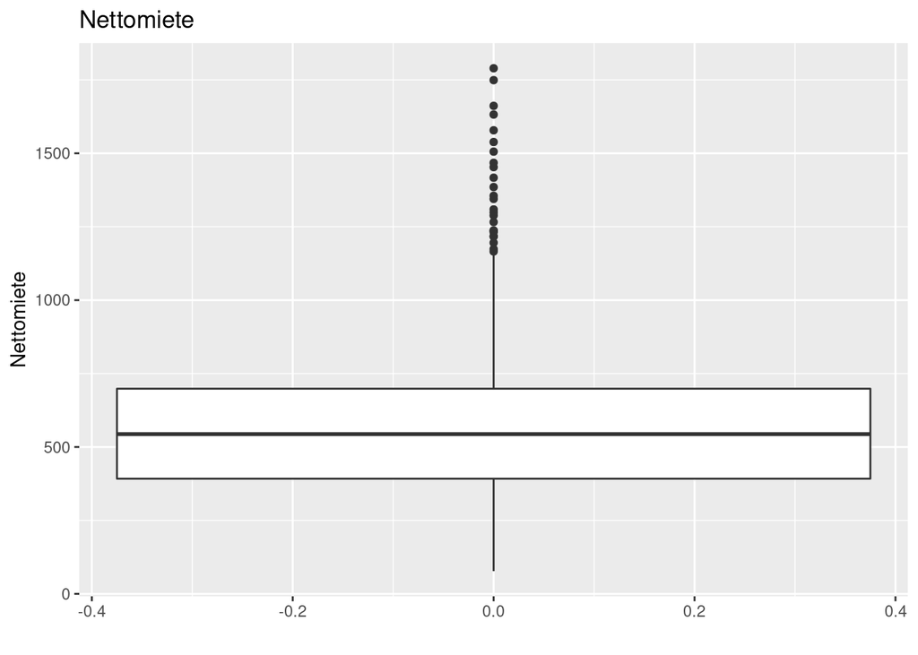

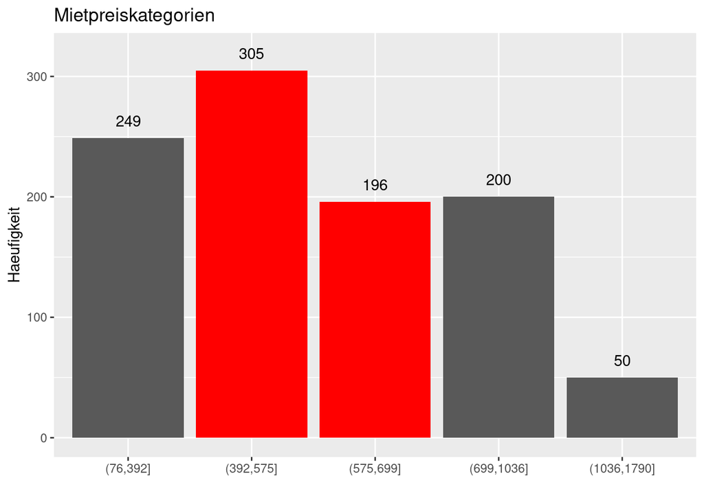

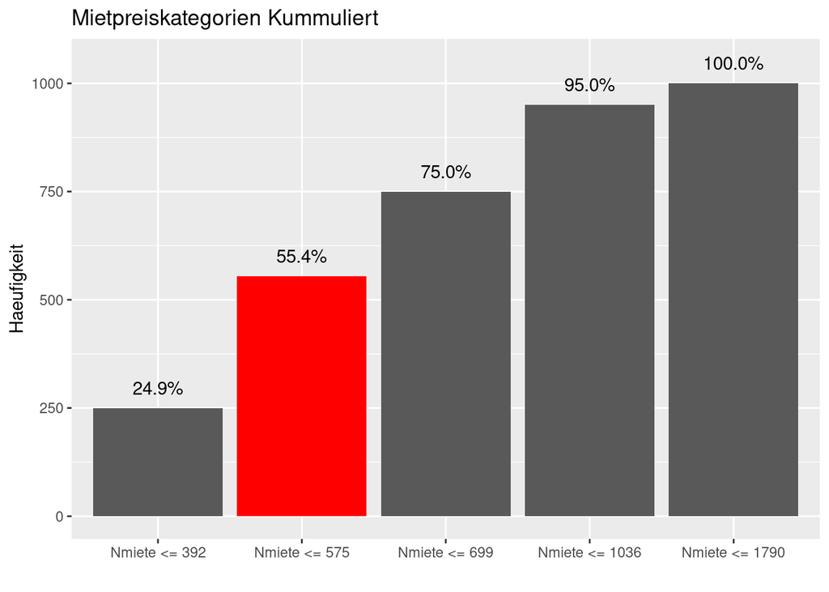

Grafik 1 (links) laesst eine symmetrische Verteilung der Nettomietpreise mit einigen Ausreissern nach oben (Schwarze Punkte) erkennen. Grafik 2 (Mitte) gibt die Anzahl der Wohnungen in den entsprechenden Nettomietenintervallen wider: 50.1% der Wohnungen hat einen Mietpreis zwischen 392-699 und jeweils ein Viertel liegt darunter und darueber. Die Intervallslaenge nimmt zu den Raendern hin deutlich waechst. Das letzte Intervall, den teuersten 50 Wohnungen (5%), entspricht ungefaehr der Zusammenlegung der ersten drei Intervalle (0-699). Grafik 3 (rechts) die kumulierten Haeufigkeiten der Nettomietpreise wieder. Man kann erkennen dass 55.4% der Wohnungen einen Nettomietpreis kleiner oder gleich 575 haben.

### Wohnflaeche

Die durchschnittliche Wohnflaeche liegt bei: 71 Quadratmeter (qm). Grafik 1 (links) deutet auf eine symmetrische Verteilung der Daten mit einigen Ausreissern nach oben. Grafik 2 (Mitte) gibt die absoluten Haeufigkeiten wieder. Die Anzahl der Wohnungen wird mit steigender Flaeche immer kleiner. Weiters nimmt die Streuung zu den Raendern hin immer mehr zu. 48.2% der Wohnungen sind auf das Intervall von 55-85 qm konzentriert (in rot markierte Balken). Mehr wie die Haelfte (54%) der Wohnungen haben eine Flaeche von 71 qm oder weniger (Grafik 3, rechts).

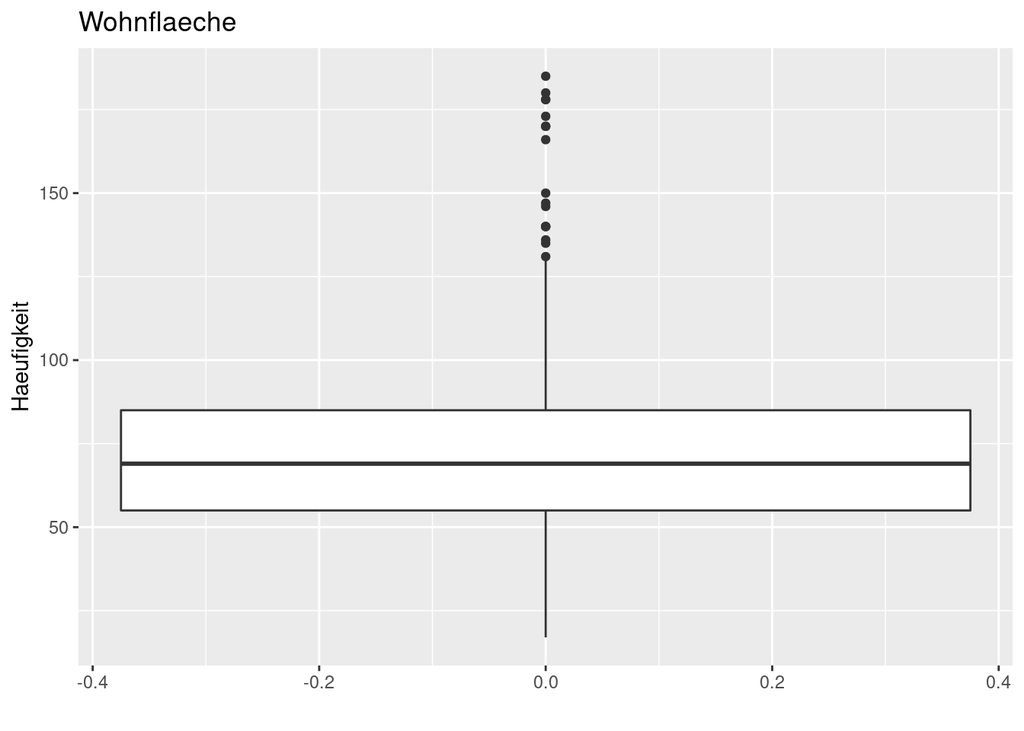

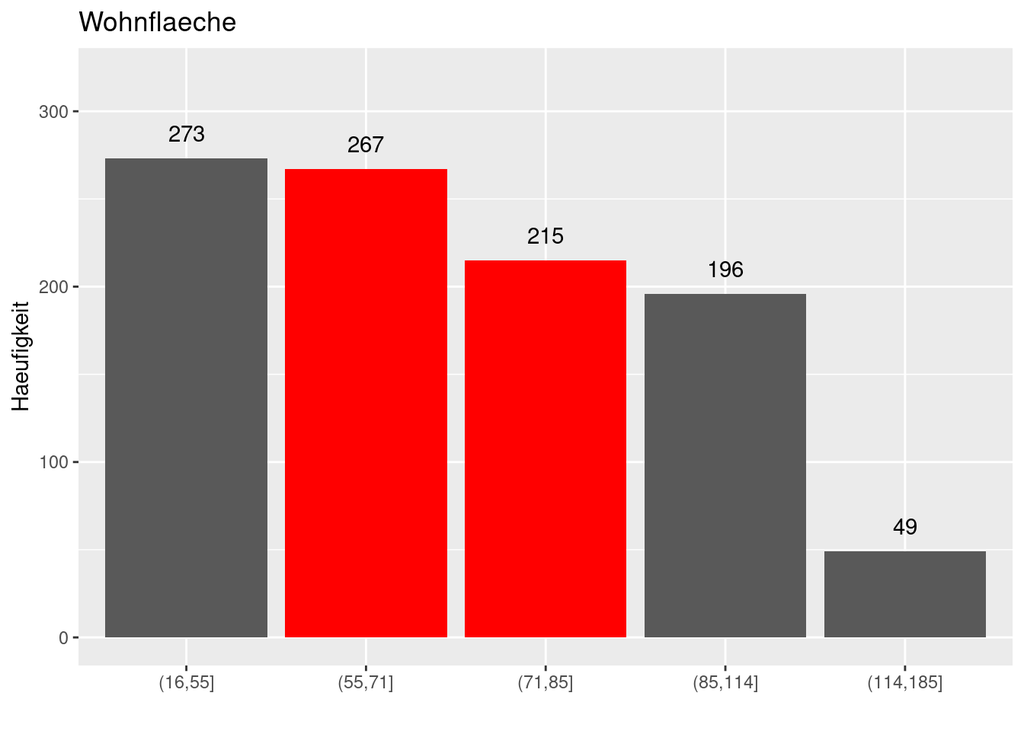

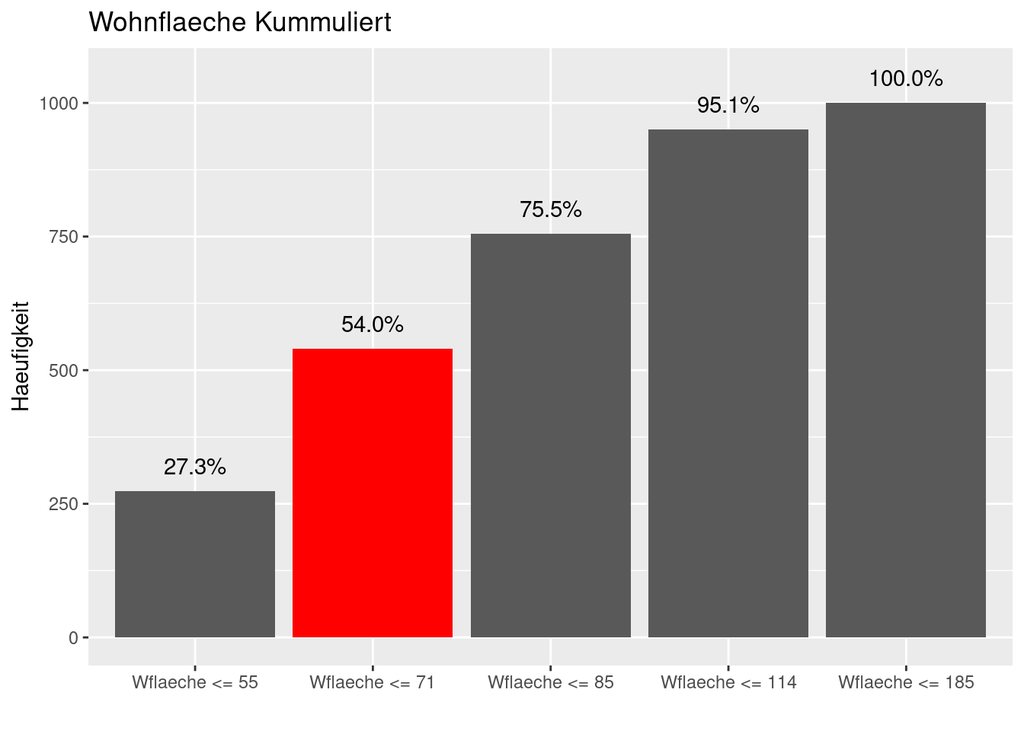

### Zimmer

71.2% der Wohnungen hat zwei oder drei Zimmer. Zu den Raendern hin nimmt die Haeufigkeit stark ab (Grafik 1, links). Deutlich vor allem die Anzahl der Wohnungen mit fuenf oder sechs Wohnungen macht 3.1 % der gesamten Wohnungen aus. 82.4% der Wohnungen haben drei oder weniger Zimmer (Grafik 2, rechts).

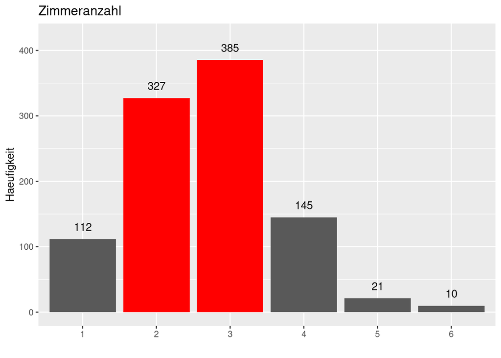

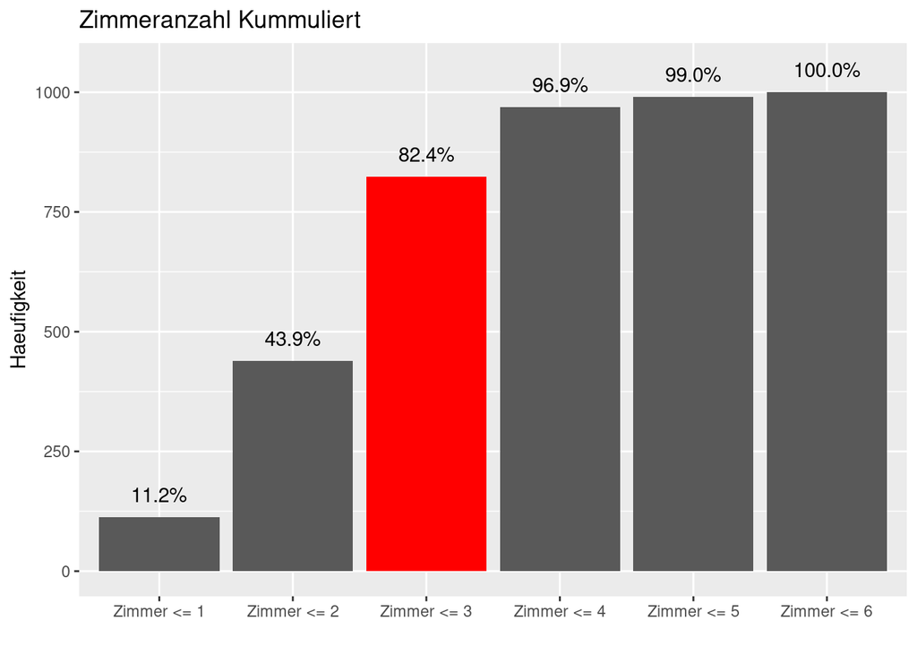

### Alter

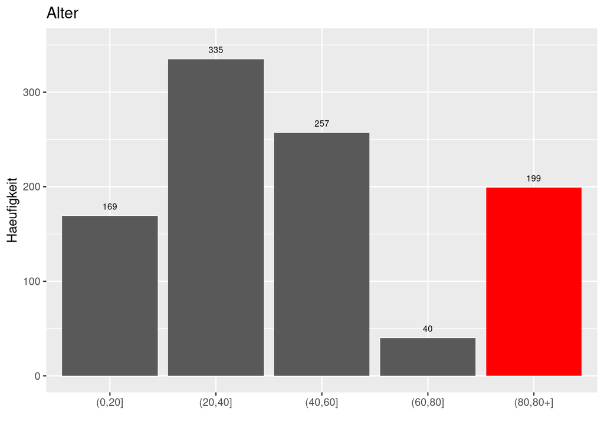

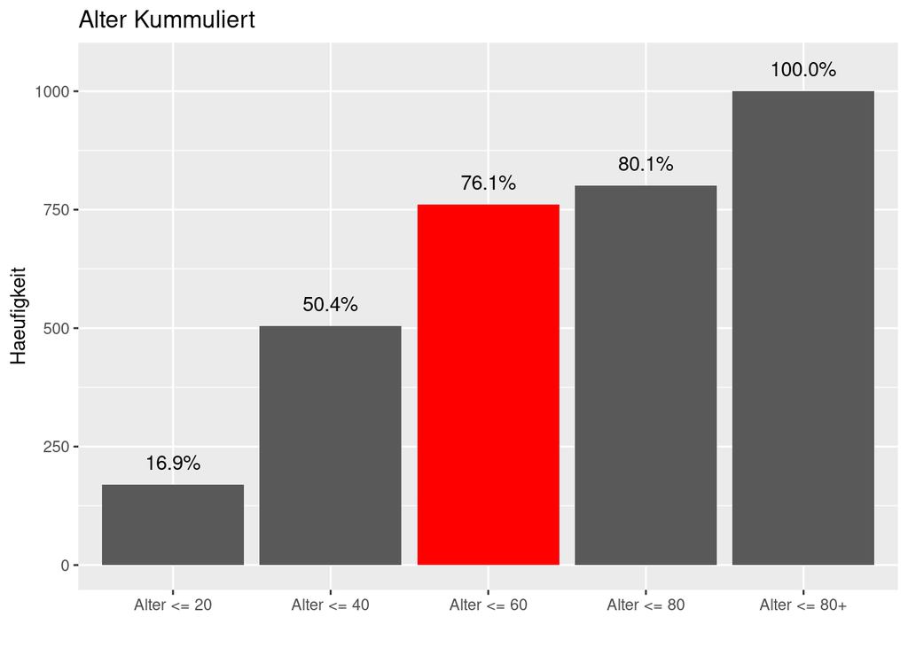

### Kategorische Variablen

Der Datensatz enthaelt zusaetzlich kategorische Variablen, deren Haeufigkeiten in den folgenden Grafiken dargestellt werden. Fuer alle folgenden Variablen lassen sich grosse Unterschiede in den Haeufigkeiten feststellen.

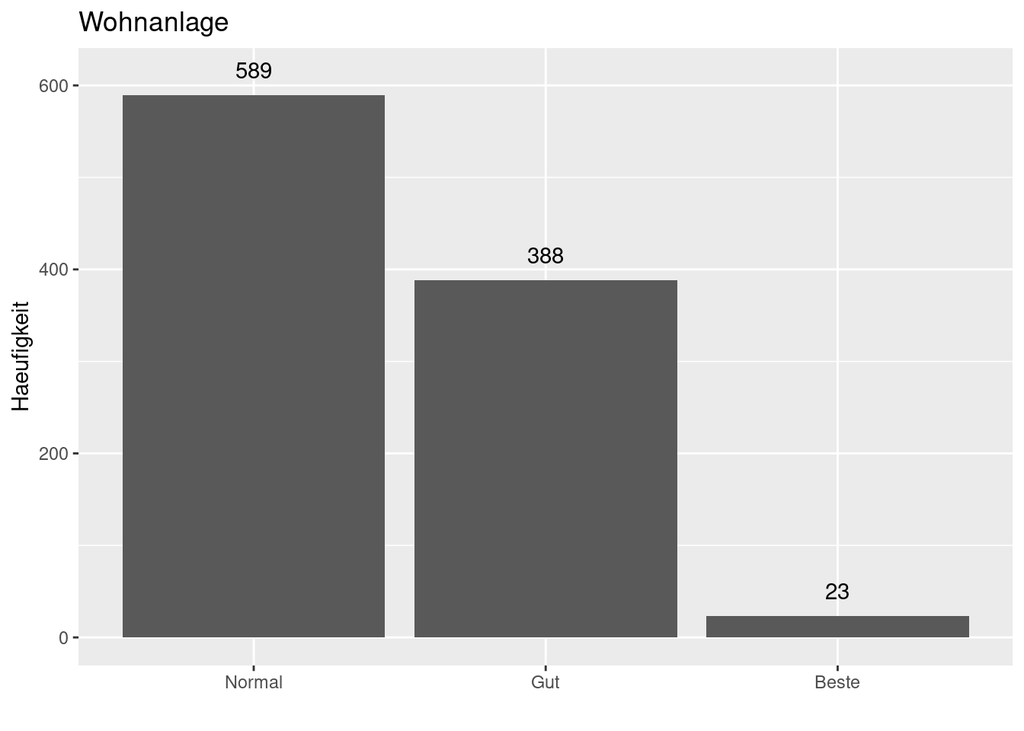

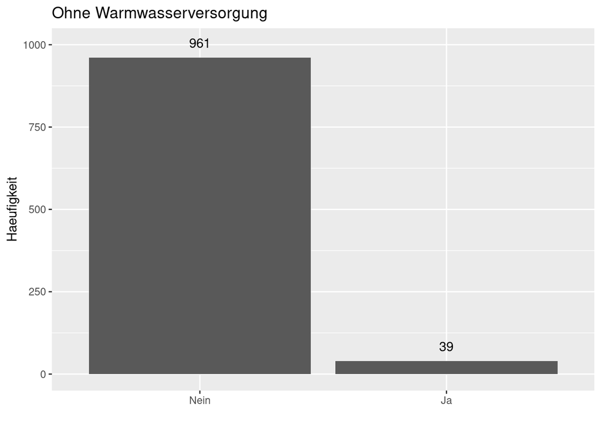

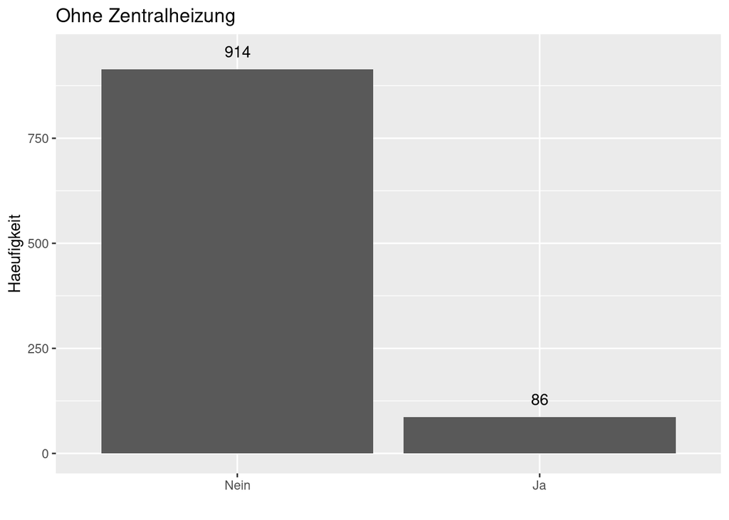

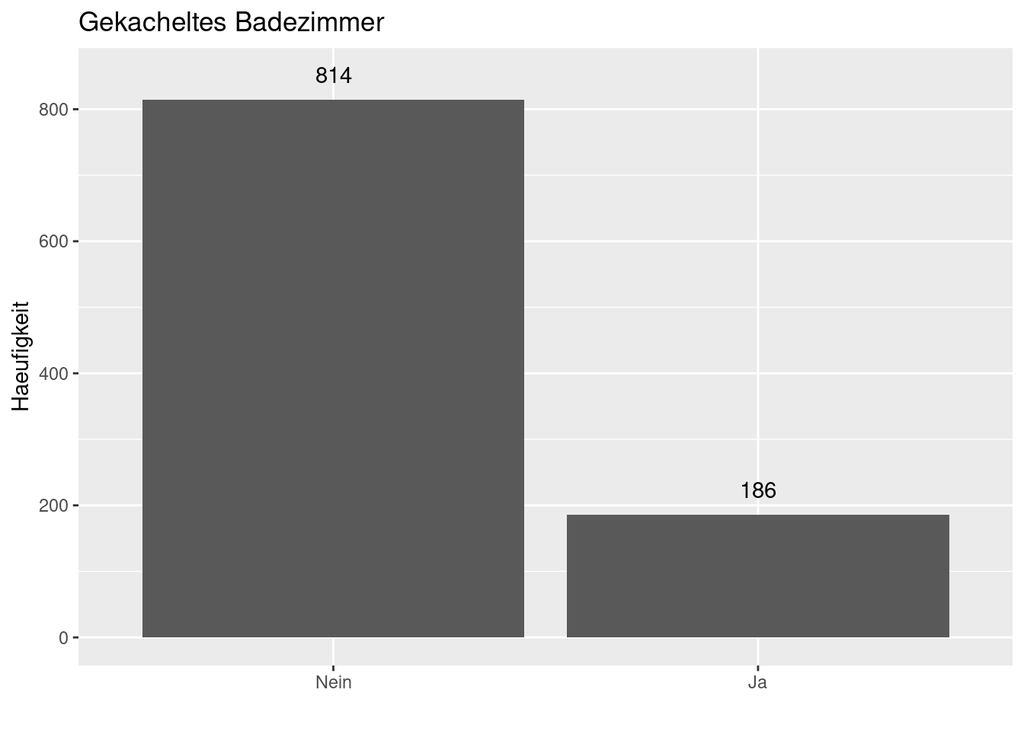

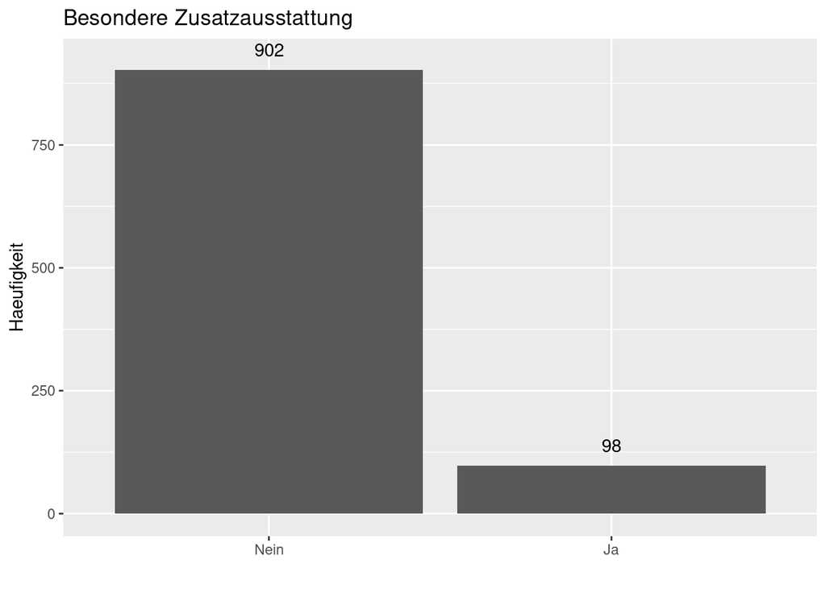

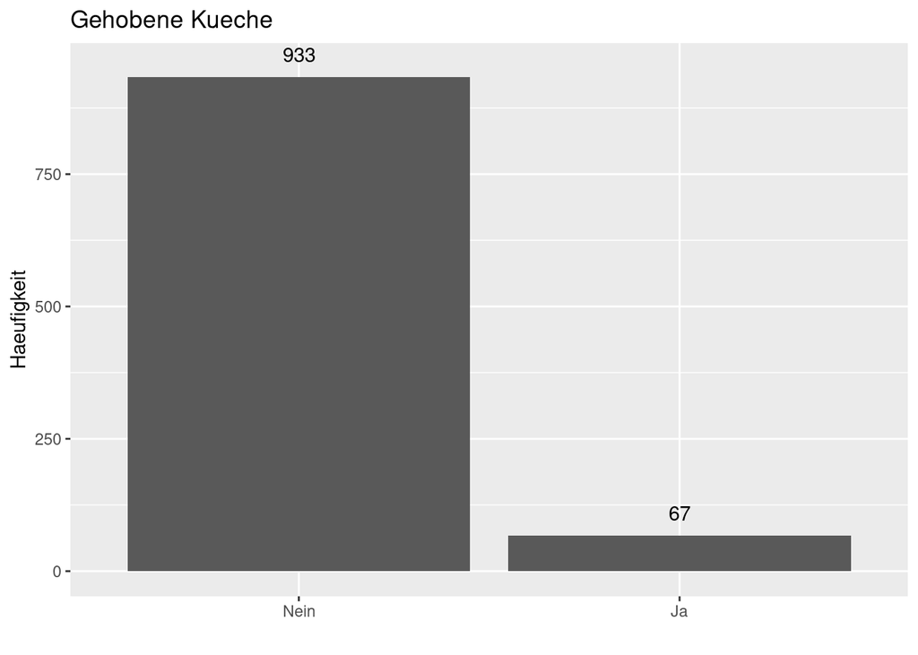

## Bivariate Analysen

Die unteren Grafik geben die Korrelationen der Variablen wieder. Die linke Grafik enthaelt alle und die rechte Grafik nur die signifikanten Korrelationen. Wie koennen beobachten: 1) Nettomiete ist mit fast allen anderen Variablen signifikant korreliert. 2) Gehobene Kueche ist mit keiner anderen Variablen signifikant korreliert. 3) Wohnflaeche und Zimmeranzahl haben die staerkste- und Nettomiete und Wohnflaeche sind am zweitstaerkste positive Korrelation.

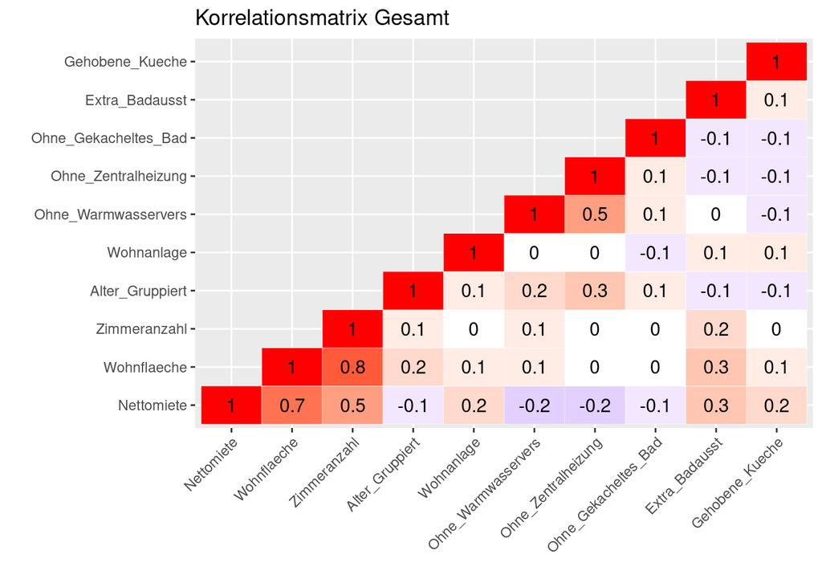

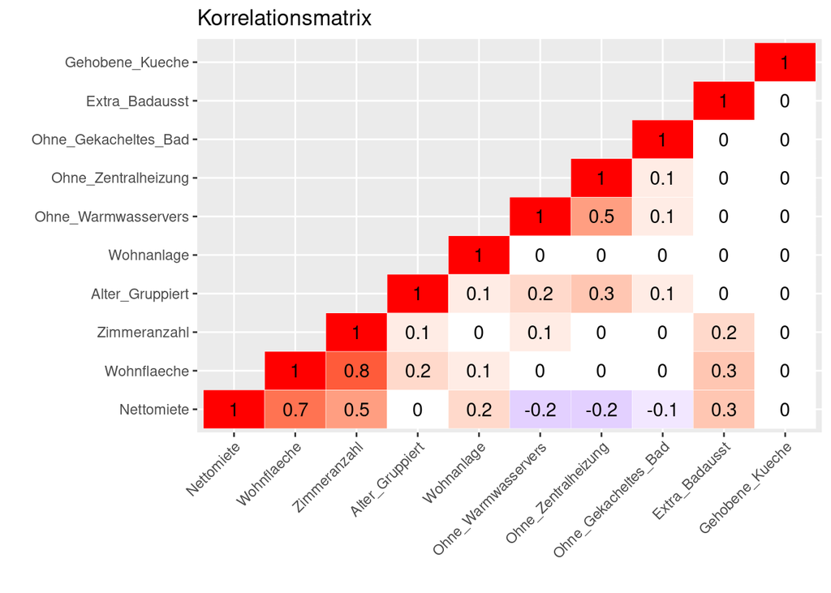

Im Folgenden wird der Zusammenhang zwischen der Nettomiete und selektierten Variablen dargestellt. Mit steigender Wohnflaeche, steigender Zimmeranzahl steigt die Nettomiete. Hier laesst sich jeweils ein linearer Zusammenhang mit steigender Streuung noch oben beobachten. Zwischen Alter und Nettomiete koennen wir einen nicht linearen Zusammenhang beobachten. Konkret steigt die Nettomiete zu den Juengsten (0 bis 20 Jahre) und den Aeltesten (80+).

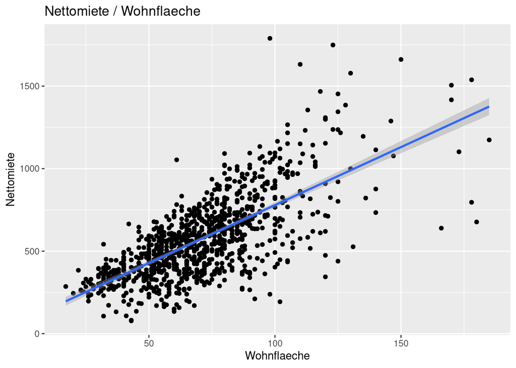

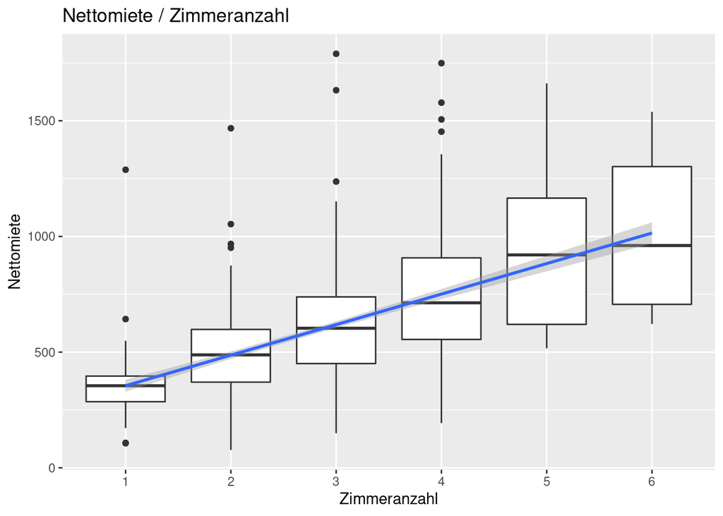

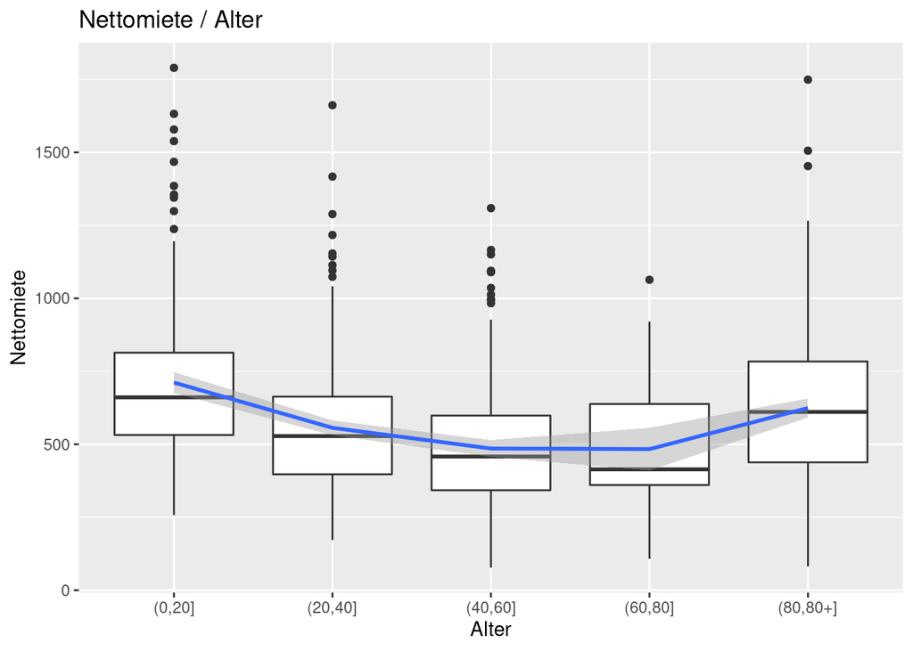

Im Folgenden wird fuer die restlichen Variablen die Nettomiete auf die entsprechenden Auspraegungen dargestellt. In allen Faellen kann man deutliche Unterschiede zwischen den Kategorien feststellen.

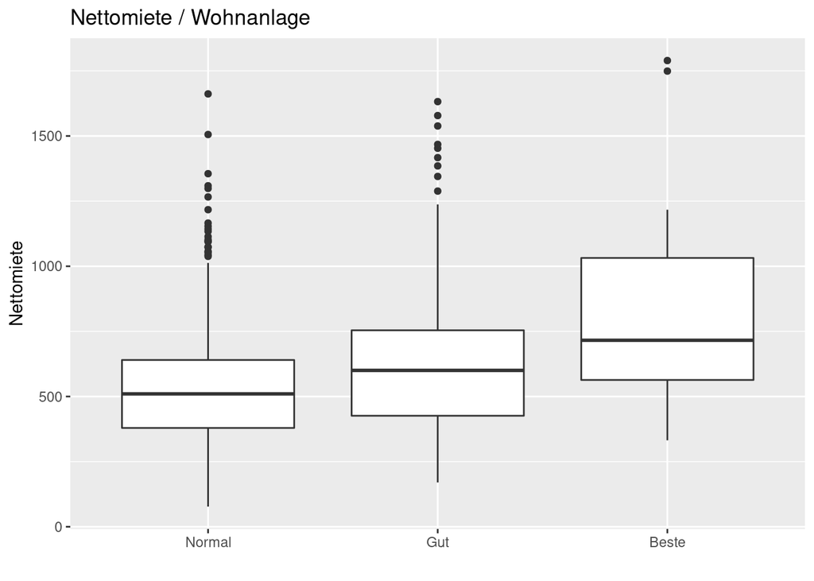

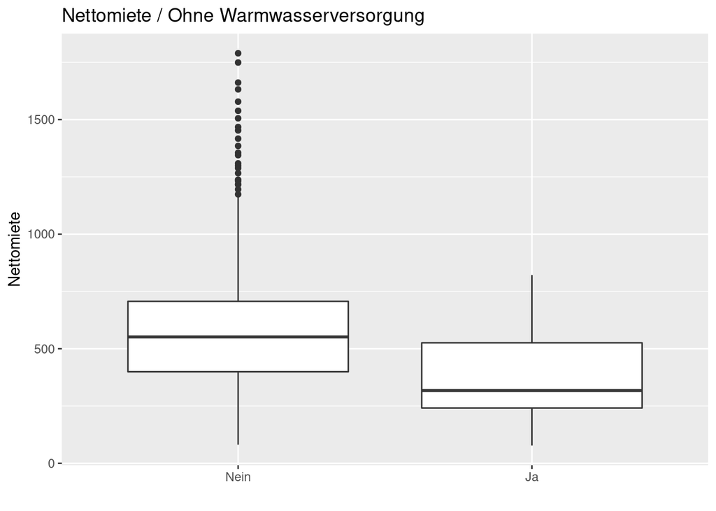

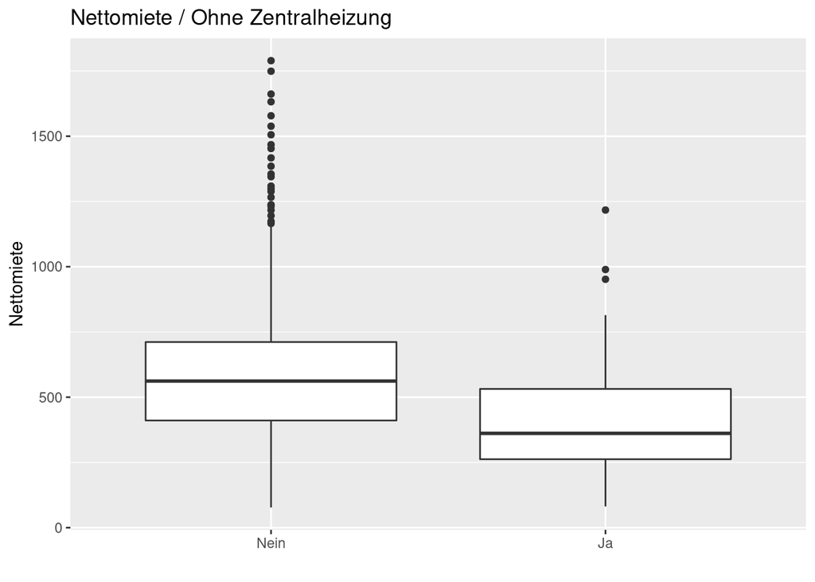

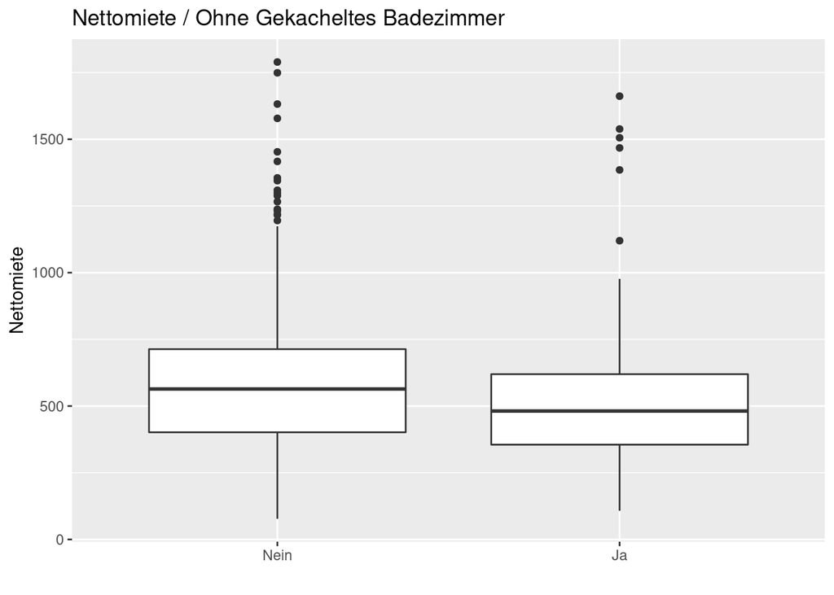

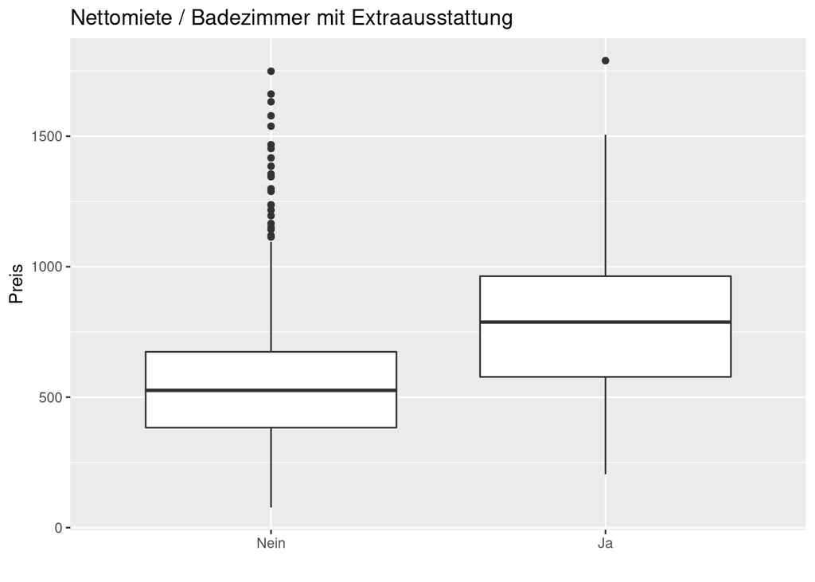

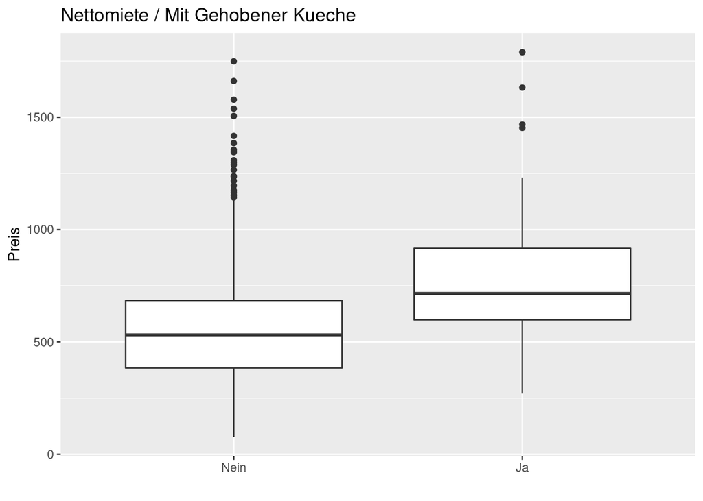

## Trivariate Analysen

Im Folgenden werden noch Zusammenhaenge zwischen dem Nettomietpreis und jeweils zwei anderen Variablen dargestellt. Diese Darstellung ermoeglicht eine differenzierte Betrachtung von Effekten die nur zwischen zwei Variablen gleichzeitig aufkommen. Auffaellige unterschiede konnten vor allem fuer die Variablen Wohnflaeche, Alter_Gruppiert und Wohnanlage festgestellt werden.

### Wohnflaeche +

Wir vermuten dass die Wohnflaeche der Massgebliche Treiber fuer den Mietpreis darstellt und betrachten somit saemtliche Modelle wo die Nettomiete durch die Wohnflaeche und noch einer weiteren Variablen dargestellt werden. Die folgende Grafiken geben jeweils die Regressionsgerade fuer die Wohnflaeche in Abhaengigkeit der zweiten Variable wieder. Interessiert sind wir insbesondere an unterschiedlichen Steigungen da diese als Indikator fuer Interaktionseffekte zwischen zwei Variablen dienen. Die folgenden Grafiken geben die entsprechenden Resultate wieder. Wir beobachten, dass die Nettiete bei Wohnflaeche und:

- Wohnungen mit sechs Zimmern (a)
- Wohnungen bis zu 20 Jahren (b)
- in bester Lage (c)
- mit Zentralheizung und (d)
- mit Gehobener Kueche (e)

sich deutlich von anderen unterscheidet.

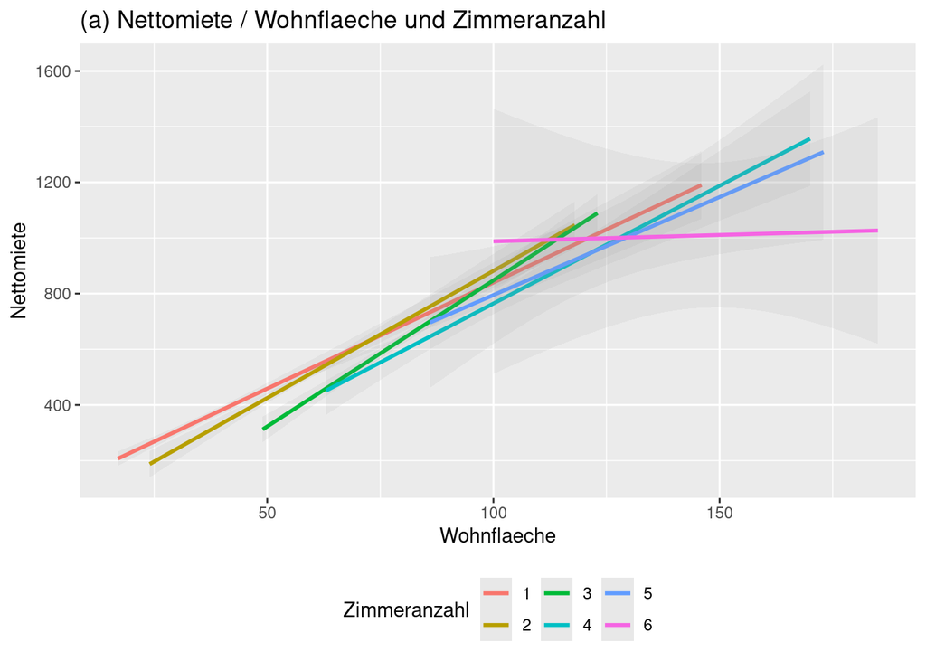

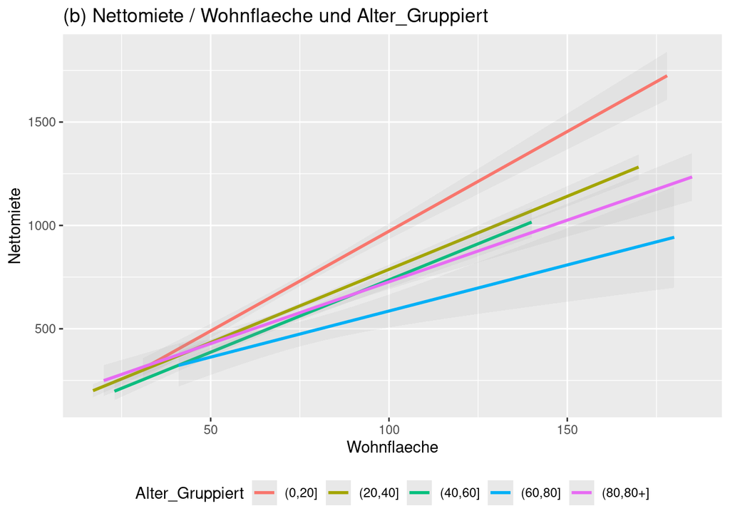

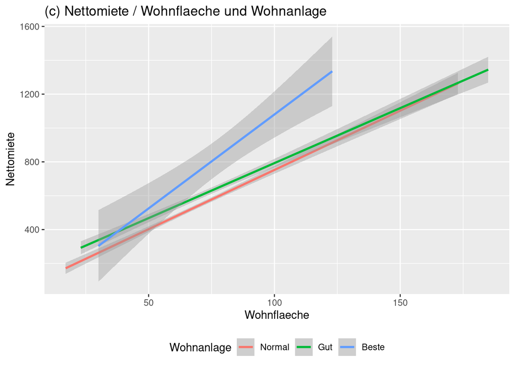

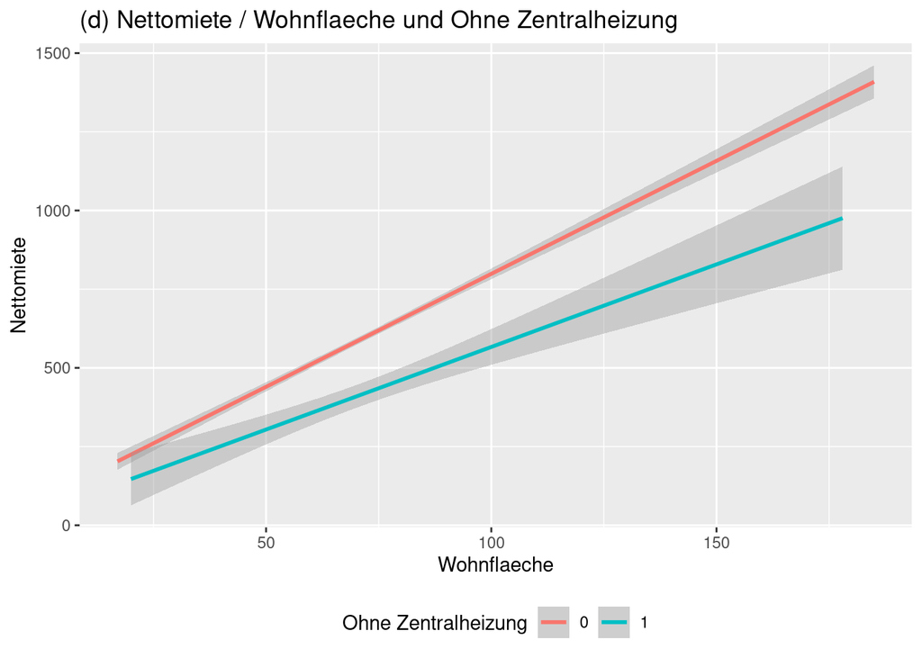

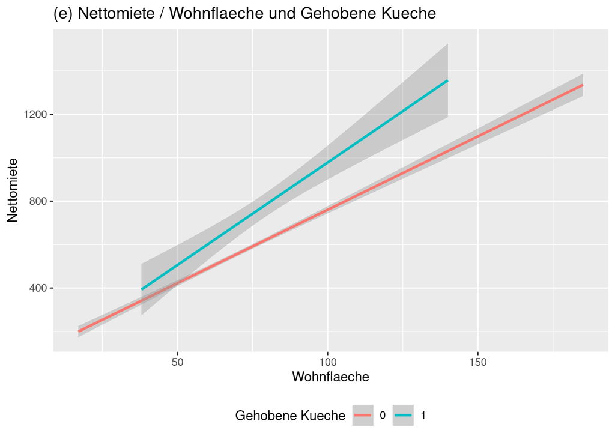